# **Project: Machine Learning: Personal Loan Campaign**

# Conclusion of Pre and Post-prunning

### Post decision tree methodology proved most effective, delivering 99% predictive accuracy alongside outstanding precision (96%) and recall rates (93%).

#### We can conclude the post-prunned model of the decision tree perfoms best as it gives the best Precision and F1 recall scores compare to Pre Pruning.

## Feature Importance

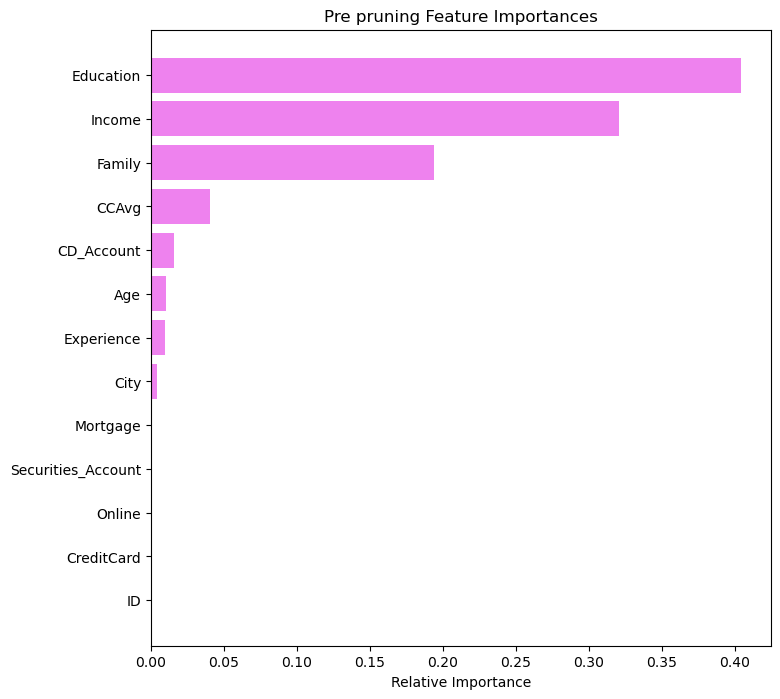

```python
# importance of features in the tree building
importances = dtree2.feature_importances_
indices = np.argsort(importances)

plt.figure(figsize=(8, 8))
plt.title("Pre pruning Feature Importances")
plt.barh(range(len(indices)), importances[indices], color="violet", align="center")
plt.yticks(range(len(indices)), [feature_names[i] for i in indices])
plt.xlabel("Relative Importance")
plt.show()
```

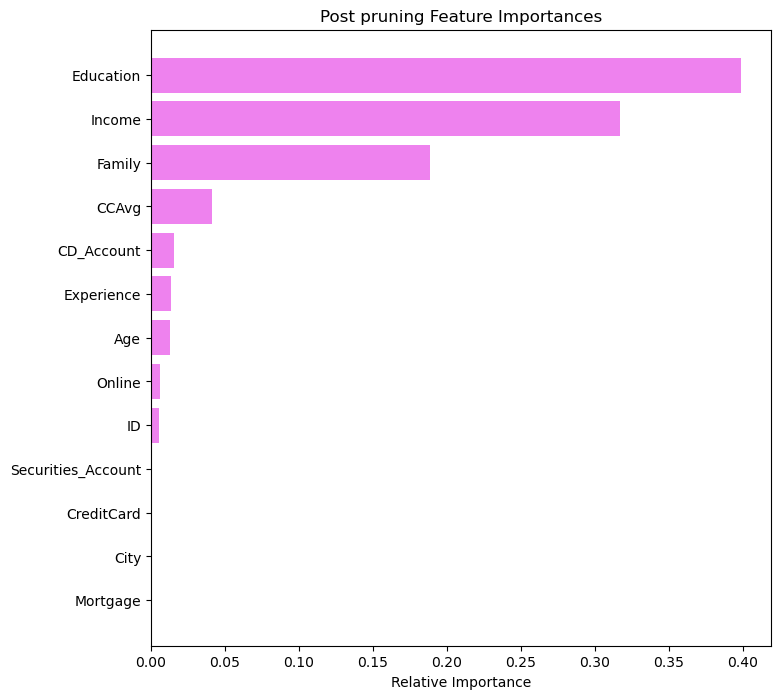

```python
# importance of features in the tree building
importances = dtree3.feature_importances_
indices = np.argsort(importances)

plt.figure(figsize=(8, 8))
plt.title("Post pruning Feature Importances")
plt.barh(range(len(indices)), importances[indices], color="violet", align="center")
plt.yticks(range(len(indices)), [feature_names[i] for i in indices])
plt.xlabel("Relative Importance")
plt.show()
```

### Education, Income,Family, CCAvg are now the top 4 important features after Pre and post pruning

```python
%%time
# choosing a data point
applicant_details = X_test.iloc[1:2, :]

# making a prediction
approval_prediction = dtree3.predict(applicant_details)

print(approval_prediction)
```

```
[1]
CPU times: total: 0 ns
Wall time: 4.23 ms
```

```python
display(applicant_details)
```

|  | ID | Age | Experience | Income | Family | CCAvg | Education | Mortgage | Securities_Account | CD_Account | Online | CreditCard | City |
| --- | --- | --- | --- | --- | --- | --- | --- | --- | --- | --- | --- | --- | --- |
| 2586 | 2587 | 47 | 23 | 149 | 4 | 6.1 | 1 | 0 | 0 | 0 | 0 | 1 | 184 |

```python
# making a prediction
approval_likelihood = dtree3.predict_proba(applicant_details)

# print the probability of class 1 (personal loan accepted)
print(approval_likelihood[0, 1])
```

```
1.0
```

# Project Synthesis and Strategic Guidance

## Overview

This analytics initiative successfully constructed predictive frameworks to pinpoint prospective personal loan clients for All Life Bank. By systematically examining customer demographic patterns, financial activities, and institutional relationships, the Post Pruning method proved most effective, delivering **99% predictive accuracy** alongside outstanding precision (**96%**) and recall rates (**93%**).

## Performance Analysis and Critical Insights

### Model Evaluation Outcomes:

- **Post-Pruning**: Exceptional results featuring 99% accuracy, 96% precision, 93% recall, and 0.95 F1-measure
- **Pre-Pruning)**: Reduced effectiveness relative to optimized version with 99% accuracy, 95% precision, 91% recall, and 0.93 F1-measure
- **sklearn default**: Exhibited overfitting challenges, confirming pruning necessity

## Strategic Implementation Framework

### 🎯 Priority Marketing Initiatives

#### Primary Audience Clusters:

1. **"Elite Career Professionals"**
   - Annual earnings exceeding $100K with graduate-level education
   - Projected conversion probability: 90%+
   - Strategic approach: Customized premium financial solutions
2. **"Expanding Households"**
   - Family units ≥ 1 member, 35-40 age bracket, property loan obligations
   - Conversion catalysts: Lifecycle requirements and financial responsibilities
   - Strategic approach: Tailored family-oriented lending options
3. **"Wealth-Protected Clients"**
   - Fixed deposit account owners with investment portfolios
   - Diminished risk characteristics with collateral capabilities
   - Strategic approach: Secured lending instruments

### 📊 Marketing Efficiency Enhancement

#### Resource Distribution:

- **Amplified Attention**: Clients with $100K+ earnings, advanced degrees, fixed deposit accounts
- **Diminished Emphasis**: Pre-retirement customers, digital-only banking users, limited-income groups
- **Experimental Focus**: High-earning clients with property loans and substantial credit card expenditure

### 🏦 Service Delivery Advancements

#### Digital Interface Upgrades:

- Streamline online loan request user interface
- Deploy customized notifications for pre-qualified segments
- Create mobile-optimized application workflows for technologically adept clients

#### Risk Assessment Protocols:

- Establish graduated interest structures aligned with identified risk categories
- Design specialized oversight for clients with elevated credit card usage despite conversion potential
- Develop proactive monitoring mechanisms utilizing decision tree parameters

### 🔍 Operational Execution Guidelines

#### Sales Force Direction:

**Immediate Engagement:**

- Clients satisfying income and education criteria
- Fixed deposit account holders with domestic responsibilities
- Mortgage clients exhibiting consistent repayment history

**Cautious Approach:**

- Elevated credit card utilization clients (default risk monitoring)
- Customers with minimal banking service utilization

**Lower Priority:**

- Approaching retirement clients (limited conversion potential)
- Exclusive digital banking users hesitant toward additional services

## Technical Deployment Timeline

### Initial Phase (30-day execution):

1. Incorporate optimized decision tree algorithm into customer management platform
2. Educate sales personnel on identified client categories
3. Launch digital engagement strategies for online banking users

### Intermediate Phase (60-day implementation):

1. Construct automated evaluation system for new client acquisitions
2. Develop performance monitoring interface for marketing initiatives
3. Initiate comparative testing for diverse promotional approaches

### Extended Phase (90+ day progression):

1. Ongoing model refinement incorporating fresh client information
2. Broaden application to forecast additional banking service adoption
3. Integrate with instantaneous customer engagement platforms

## Risk Assessment and Countermeasures

### Technical Vulnerabilities:

- **Income parameter dependency**: Track economic fluctuations influencing client earnings
- **Temporal data variance**: Conduct quarterly model verification
- **Inaccurate predictions**: Preserve expert evaluation for significant decisions

### Commercial Vulnerabilities:

- **Segment overconcentration**: Prevent excessive focus on individual customer groups
- **Market competition**: Anticipate rival responses to effective targeting
- **Legal adherence**: Verify targeting methodologies comply with equitable lending regulations

## Concluding Assessment

The refined decision tree methodology equips All Life Bank with a sophisticated, practical instrument for personal loan client identification. Through concentration on established high-probability segments and execution of recommended strategic measures, the institution can anticipate:

- **Enhanced conversion rates** through 90%+ accurate client targeting
- **Optimized marketing expenditure** via concentrated resource distribution
- **Superior client satisfaction** through individualized, appropriate proposals
- **Advanced risk assessment** utilizing evidence-based decision frameworks